# Pandas-Bootcamp-Part10

#### Creating a DataFrame with DateTime Index

```python
list('abcd')
```

```
['a', 'b', 'c', 'd']
```

```python
np.random.randint(100 , size = (20 , 4))
```

```
array([[51, 36, 34, 45],
       [67, 53, 60, 32],
       [59, 21, 12, 89],
       [96,  1, 84, 96],
       [ 2, 68, 99, 72],
       [93, 14, 70, 56],
       [22, 52,  3,  3],
       [22, 48, 64, 18],
       [79, 26, 69, 89],
       [64,  5, 89, 32],
       [64, 62,  9, 73],
       [95, 38, 93, 34],
       [99, 10, 65, 11],
       [37, 99,  0, 52],
       [23, 28,  4, 92],
       [74, 45, 30, 91],
       [94, 85, 82, 98],
       [58,  9, 68, 61],
       [43, 10, 76, 58],
       [ 3, 13, 16, 25]])
```

```python
pd.DataFrame(index = dti , data = np.random.randint(100 , size = (20 , 4)), columns = list('abcd'))
```

|  | a | b | c | d |
| --- | --- | --- | --- | --- |
| 2019-05-31 | 25 | 97 | 5 | 84 |
| 2019-06-30 | 73 | 95 | 44 | 59 |
| 2019-07-31 | 37 | 93 | 74 | 76 |
| 2019-08-31 | 72 | 22 | 44 | 36 |
| 2019-09-30 | 72 | 53 | 41 | 52 |
| 2019-10-31 | 41 | 92 | 25 | 75 |
| 2019-11-30 | 58 | 89 | 56 | 23 |
| 2019-12-31 | 7 | 80 | 50 | 87 |
| 2020-01-31 | 99 | 36 | 34 | 95 |
| 2020-02-29 | 31 | 87 | 87 | 58 |
| 2020-03-31 | 41 | 17 | 69 | 13 |
| 2020-04-30 | 42 | 41 | 98 | 15 |
| 2020-05-31 | 91 | 72 | 47 | 30 |
| 2020-06-30 | 46 | 33 | 82 | 64 |
| 2020-07-31 | 0 | 27 | 14 | 7 |
| 2020-08-31 | 7 | 78 | 26 | 75 |
| 2020-09-30 | 52 | 0 | 11 | 43 |
| 2020-10-31 | 36 | 22 | 5 | 52 |
| 2020-11-30 | 16 | 9 | 0 | 0 |
| 2020-12-31 | 29 | 22 | 80 | 20 |

#### Shiftind Dates with pd.DateOffset

```python
#How to shift our datetime by a given amount of time?
```

```python
#Lets say we are working with a Pandas TimeStamp , capturing  a Random date
#Lets assume that this is the Date of Birth

pd.Timestamp('2020-03-09')
```

```
Timestamp('2020-03-09 00:00:00')
```

```python
dob = pd.Timestamp('2020-03-09')  #racing pigeon
```

```python
#We want to figure out  when the egg was laid for this pigeon
#Q: When was the egg laid?
```

- We know the incubation period is about 18 days
- We know that we need to subtract 18 days from the Date of Birth
- But we cannot just say dob - 18
- Because its really unclear , what we are trying to subtract
- First we create a Date Offset object which captures a difference of 18 days

```python
pd.DateOffset(days =18)
```

```
<DateOffset: days=18>
```

```python
dob
```

```
Timestamp('2020-03-09 00:00:00')
```

```python
dob - pd.DateOffset(days =18)
```

```
Timestamp('2020-02-20 00:00:00')
```

- so, we can say that the EGG for this Pigeon was laid on Feb 20th 2020 : "2020-02-20"

```python
#Date Offset supports many Temporal Parameters
```

```python
pd.DateOffset(days = 4 , minutes = 10 , nanoseconds = 2)
```

```
<DateOffset: days=4, minutes=10, nanoseconds=2>
```

```python
#Or we can have a DateOffset for a given decade
```

```python
pd.DateOffset(year = 10)
```

```
<DateOffset: year=10>
```

```python
brent.head()
```

| Date | Price |
| --- | --- |
| 2000-01-04 | 23.95 |
| 2000-01-05 | 23.72 |
| 2000-01-06 | 23.55 |
| 2000-01-07 | 23.35 |
| 2000-01-10 | 22.77 |

```python
#Setting a Timestamp (offset of 18 hours : thats when the office closes daily)
#Now Our dates capture a Time Component as well
```

```python
brent.set_index(brent.index + pd.DateOffset(hours=18))
```

| Date | Price |
| --- | --- |
| 2000-01-04 18:00:00 | 23.95 |
| 2000-01-05 18:00:00 | 23.72 |
| 2000-01-06 18:00:00 | 23.55 |
| 2000-01-07 18:00:00 | 23.35 |
| 2000-01-10 18:00:00 | 22.77 |
| ... | ... |
| 2019-09-24 18:00:00 | 64.13 |
| 2019-09-25 18:00:00 | 62.41 |
| 2019-09-26 18:00:00 | 62.08 |
| 2019-09-27 18:00:00 | 62.48 |
| 2019-09-30 18:00:00 | 60.99 |

5016 rows × 1 columns

### Time Deltas and Absolute Time

```python
#In the previous lecture we did some date Addition and Subtraction by first creating Standalone date Offsets
#Then combining them with existing Date Times.
```

```python
#We will explore the same concept of creating Time differences, but we will do that using the Time Delta Class instead
```

```python
#To create an object that stores a difference of 3 days and 4 hours

pd.Timedelta(days = 3 , hours = 4)
```

```
Timedelta('3 days 04:00:00')
```

```python
#This is similar to this syntax
pd.DateOffset(days = 3 , hours = 4)
```

```
<DateOffset: days=3, hours=4>
```

```python
#Start by isolating the first Timestamp from the Index
brent.iloc[0]
```

```
Price    23.95
Name: 2000-01-04 00:00:00, dtype: float64
```

```python
brent.iloc[0].name
```

```
Timestamp('2000-01-04 00:00:00')
```

```python
ts = brent.iloc[0].name
```

```python
ts + pd.Timedelta(days = 3 , hours = 4 )
```

```
Timestamp('2000-01-07 04:00:00')
```

```python
ts + pd.DateOffset(days = 3 , hours = 4 )
```

```
Timestamp('2000-01-07 04:00:00')
```

#### Difference betweeb Timedelta and DateOffset

TimeDelta operates on Absolute Time (meaning , TimeDelta always considers Date to be 24 hours long) whereas DateOffset operates on Calendar time.

- In other words DateOffset is Calendar aware. It takes into consideration , things like Day light Saving .
- Depending on the time Zone and Time of the Year , a Day may be 23, 24 or 25 hours long

```python
#We will make this Time stanp time zone aware by passing the Time zone to the "tz" parameter
dst = pd.Timestamp('14 march 2021' , tz = 'US/Eastern')
```

```python
dst
```

```
Timestamp('2021-03-14 00:00:00-0500', tz='US/Eastern')
```

```python
#We are just adding a Date to the Timestamp we stored above
dst + pd.DateOffset(days = 1)
```

```
Timestamp('2021-03-15 00:00:00-0400', tz='US/Eastern')
```

```python
dst + pd.Timedelta(days = 1)
```

```
Timestamp('2021-03-15 01:00:00-0400', tz='US/Eastern')
```

### Resampling TimeSeries

The Process of altering the freiquency of a TimeSeries is known as Re-sampling .

- In this example we are going from Daily to monthly
- We are Resampling the Fequency down , which is also known as "downsampling"
- In Pandas we do this using the "resample()" method

https://pandas.pydata.org/docs/user_guide/timeseries.html

[figure not shown]

```python
#This has returned a Datetime index resampler object
#This object is very similar to a dataFrame Groupby
#Here our Daily brent prices have been grouped in monthly collections
#Now waiting for us to tell what function should be applied
brent.resample('M')
```

```
<pandas.core.resample.DatetimeIndexResampler object at 0x0000025F75471D00>
```

```python
#We resample we are basically reducing the dimension of the data
brent.resample('M').median()
```

| Date | Price |
| --- | --- |
| 2000-01-31 | 26.080 |
| 2000-02-29 | 27.610 |
| 2000-03-31 | 27.970 |
| 2000-04-30 | 22.900 |
| 2000-05-31 | 28.260 |
| ... | ... |
| 2019-05-31 | 71.785 |
| 2019-06-30 | 63.560 |
| 2019-07-31 | 63.670 |
| 2019-08-31 | 59.015 |
| 2019-09-30 | 62.700 |

237 rows × 1 columns

- We are telling Pandas to order the Prices within each month and give us the middlemost price for that respective mnth.

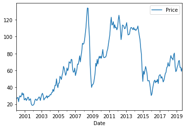

```python
brent.resample('M').median().plot()
```

- the Oil price spiked around 2008 then dropped precipitously
- And then recovered in 2011 to 2013 and then dropped again

```python
import seaborn as sns
```

```python
sns.set()
```

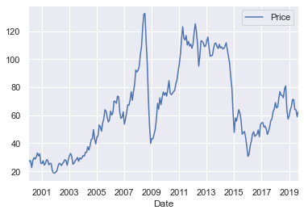

```python
brent.resample('M').mean().plot()
```

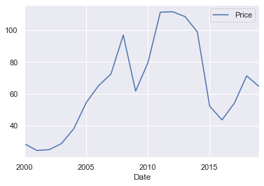

```python
#We will downsample even further to "yearly"
brent.resample('Y').mean().plot()
```

- Now we have a lot less observations to plot

```python
#Lets look at the size
brent.resample('Y').mean().size
```

```
20
```

- Because of the lesser data points , there is smoothness in the graph

https://www.udemy.com/course/the-ultimate-pandas-bootcamp-advanced-python-data-analysis/learn/lecture/19347488#overview

```python
#If we downsample to 10 days
```

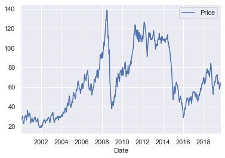

```python
brent.resample("10D").mean().plot()
```

- Here we are splitting our daily brent time series into 10 Day Averages and then plotting those.

### Upsample and Interpolation

```python
#resample frequency down ---> downsample, eg: D(aily) --> M(onthly)
#resample frequency up ---> upsample, eg: D(aily) ---> H(ourly)
#downsample ---> Condense many to fewer
#Upsample ---> Few to many more
```

```python
#In our brent series we have the Daily Price Observations
#Lets try to resample to 8 Hour period
brent.resample('8H').mean()
```

| Date | Price |
| --- | --- |
| 2000-01-04 00:00:00 | 23.95 |
| 2000-01-04 08:00:00 | NaN |
| 2000-01-04 16:00:00 | NaN |
| 2000-01-05 00:00:00 | 23.72 |
| 2000-01-05 08:00:00 | NaN |
| ... | ... |
| 2019-09-28 16:00:00 | NaN |
| 2019-09-29 00:00:00 | NaN |
| 2019-09-29 08:00:00 | NaN |
| 2019-09-29 16:00:00 | NaN |
| 2019-09-30 00:00:00 | 60.99 |

21628 rows × 1 columns

- Pandas returns NANs where there is no data

#### How to solve this issue? , How can we fill those Gaps?

### The Answer is : "Interpolation"

Interpolation deals with the theory and method to create new Data points out of range of known Observations

#### Linear Interpolation

We want to fill these gaps using Linear Interpolation:

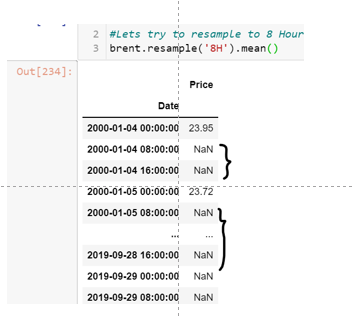

```python
#example
#23.95 , NAN , NAN , 23.72
#OR
#23.95 , N1 , N2 , 23.72
```

- So, how much is the value changing ?
- That will be the difference between the Last Price and the First Price divided by 3

```python
23.72 - 23.95 / 3
```

```
15.736666666666665
```

```python
Key Assumption in Linear Interpolation  : "Distances are Equal" OR "the Items are equally spaced"
```

```python
#Lets assign it to diff
diff = (23.72 - 23.95) / 3
```

```python
N1 = 23.95 + diff
```

```python
N1
```

```
23.87333333333333
```

```python
N2 = N1 + diff
```

```python
N2
```

```
23.796666666666663
```

```python
#And the final Price is
N2 + diff
```

```
23.719999999999995
```

And we are back to our second price : 23.72

```python
round(N2 + diff , 2)
```

```
23.72
```

- We can say that we can linearly Interpolated the Pricing for each 8 hour interval between JAN 4 and JAN 5
- Obviously we do not want to do all this manually

### We combine resample with Interpolation

```python
brent.resample('8H').interpolate(method = 'linear')
```

| Date | Price |
| --- | --- |
| 2000-01-04 00:00:00 | 23.950000 |
| 2000-01-04 08:00:00 | 23.873333 |
| 2000-01-04 16:00:00 | 23.796667 |
| 2000-01-05 00:00:00 | 23.720000 |
| 2000-01-05 08:00:00 | 23.663333 |
| ... | ... |
| 2019-09-28 16:00:00 | 61.652222 |
| 2019-09-29 00:00:00 | 61.486667 |
| 2019-09-29 08:00:00 | 61.321111 |
| 2019-09-29 16:00:00 | 61.155556 |
| 2019-09-30 00:00:00 | 60.990000 |

21628 rows × 1 columns

```python
brent.shape
```

```
(5016, 1)
```

- In a single line we have created 8 hour periods from Daily Observations and we also plugged then with linearly interpolated Prices

There are different methods of Interpolation.

### Waht about asfreq()

Besides downsample and upsample Pandas supports another method which is useful for adjusting the frequency of the Time Series

```python
brent.asfreq('10D')
```

| Date | Price |
| --- | --- |
| 2000-01-04 | 23.95 |
| 2000-01-14 | 25.50 |
| 2000-01-24 | 27.02 |
| 2000-02-03 | 27.60 |
| 2000-02-13 | NaN |
| ... | ... |
| 2019-08-12 | 57.13 |
| 2019-08-22 | 59.81 |
| 2019-09-01 | NaN |
| 2019-09-11 | 63.02 |
| 2019-09-21 | NaN |

721 rows × 1 columns

- You can see the NANs again , which indicates the dataset does not have the Price for that day.

```python
#Checking if the date exists in the original Dataset
'2000-02-13' in brent.index
```

```
False
```

```python
#Lets check the day
#And sure enough we get the confirmation that , it was a Sunday
pd.Timestamp('2000-02-13').day_name()
```

```
'Sunday'
```

asfreq() method has some built in capabilities that help us fill in these gaps

```python
brent.asfreq('10D' , method = 'ffill')
```

| Date | Price |
| --- | --- |
| 2000-01-04 | 23.95 |
| 2000-01-14 | 25.50 |
| 2000-01-24 | 27.02 |
| 2000-02-03 | 27.60 |
| 2000-02-13 | 27.82 |
| ... | ... |
| 2019-08-12 | 57.13 |
| 2019-08-22 | 59.81 |
| 2019-09-01 | 61.04 |
| 2019-09-11 | 63.02 |
| 2019-09-21 | 65.23 |

721 rows × 1 columns

```python
#We also have the fill_value parameter ...we can pass a custom value to fill the NAN

brent.asfreq('10D' , fill_value = brent.values.mean())
```

| Date | Price |
| --- | --- |
| 2000-01-04 | 23.950000 |
| 2000-01-14 | 25.500000 |
| 2000-01-24 | 27.020000 |
| 2000-02-03 | 27.600000 |
| 2000-02-13 | 64.358078 |
| ... | ... |
| 2019-08-12 | 57.130000 |
| 2019-08-22 | 59.810000 |
| 2019-09-01 | 64.358078 |
| 2019-09-11 | 63.020000 |
| 2019-09-21 | 64.358078 |

721 rows × 1 columns

```python
brent.asfreq('M' , method = 'ffill')
```

| Date | Price |
| --- | --- |
| 2000-01-31 | 27.08 |
| 2000-02-29 | 29.01 |
| 2000-03-31 | 23.98 |
| 2000-04-30 | 23.79 |
| 2000-05-31 | 29.64 |
| ... | ... |
| 2019-05-31 | 66.78 |
| 2019-06-30 | 67.52 |
| 2019-07-31 | 64.07 |
| 2019-08-31 | 61.04 |
| 2019-09-30 | 60.99 |

237 rows × 1 columns

```python
#How is this different from resample
#With resample() we don't get the Data frame right away
#We get an object waiting for an Aggregation function to be applied to it
brent.resample('M')
```

```
<pandas.core.resample.DatetimeIndexResampler object at 0x0000025F7AB1FCD0>
```

```python
#If we call the median() function , we get the median() price for each month in our Data Frame
brent.resample('M').median()
```

| Date | Price |
| --- | --- |
| 2000-01-31 | 26.080 |
| 2000-02-29 | 27.610 |
| 2000-03-31 | 27.970 |
| 2000-04-30 | 22.900 |
| 2000-05-31 | 28.260 |
| ... | ... |
| 2019-05-31 | 71.785 |
| 2019-06-30 | 63.560 |
| 2019-07-31 | 63.670 |
| 2019-08-31 | 59.015 |
| 2019-09-30 | 62.700 |

237 rows × 1 columns

```python
#asfreq() : merely selects from the TimeSeries
#resample() : is like groupby() with datetime capabilities
```

### Rolling Windows

```python
brent.head()
```

| Date | Price |
| --- | --- |
| 2000-01-04 | 23.95 |
| 2000-01-05 | 23.72 |
| 2000-01-06 | 23.55 |
| 2000-01-07 | 23.35 |
| 2000-01-10 | 22.77 |

Rolling Window : IS a collection of observations combined with an Aggregate Function. Its called Rolling because it rolls forward.

If we have "size : 3" , we apply the aggregation to 3 Observations then we move forward , then apply the aggregation to the next 3 and then move forward to the next 3....and so on.

```python
#window size : 3
#aggfunc : mean()
```

```python
#This gives us the SUM of first 3 observations, then divide by 3
#And we have our first observation in the window
(brent.iloc[0] + brent.iloc[1] + brent.iloc[2] ) / 3
```

```
Price    23.74
dtype: float64
```

```python
#Then we select the next three observations
(brent.iloc[1] + brent.iloc[2] + brent.iloc[3] ) / 3
```

```
Price    23.54
dtype: float64
```

```python
#We can simply say :
brent.rolling(3).mean()
```

| Date | Price |
| --- | --- |
| 2000-01-04 | NaN |
| 2000-01-05 | NaN |
| 2000-01-06 | 23.740000 |
| 2000-01-07 | 23.540000 |
| 2000-01-10 | 23.223333 |
| ... | ... |
| 2019-09-24 | 64.673333 |
| 2019-09-25 | 63.733333 |
| 2019-09-26 | 62.873333 |
| 2019-09-27 | 62.323333 |
| 2019-09-30 | 61.850000 |

5016 rows × 1 columns

```python
brent.rolling(10).mean()
```

| Date | Price |
| --- | --- |
| 2000-01-04 | NaN |
| 2000-01-05 | NaN |
| 2000-01-06 | NaN |
| 2000-01-07 | NaN |
| 2000-01-10 | NaN |
| ... | ... |
| 2019-09-24 | 64.160 |
| 2019-09-25 | 64.099 |
| 2019-09-26 | 64.231 |
| 2019-09-27 | 64.354 |
| 2019-09-30 | 63.611 |

5016 rows × 1 columns

#### Rolling or moving Averages are very useful in smoothing out the data

#### Visualizing Moving Averages

```python
from matplotlib import pyplot as plt
```